# output: html_document

## Test and training data generation

```r
# Preparación de training y test
ratioTrain <- 0.8
ratioTest <- 1-ratioTrain

# df <- df.all
# subsampling positive class

df <- subset(df.all, Class == "Yes")
df <- rbind(df,
            subset(df.all, Class == "No")[sample(1:nrow(subset(df.all, Class == "No")),
                                                 1.3*nrow(subset(df.all, Class == "Yes")), replace=FALSE),])

# table(df$Class)

#set.seed(42)
index <- createDataPartition(df$Class, p=ratioTrain, list=FALSE)
train.leasing <- df[index,]
test.leasing  <- df[-index,]
table(train.leasing$Class)
```

```
##
##   Yes    No
## 16756 21782
```

```r
table(test.leasing$Class)
```

```
##
##  Yes   No
## 4188 5445
```

```r
## if negative, use all instances for training
if (n.sample.train < 0) { n.sample.train = nrow(train.leasing) }
if (n.sample.train > nrow(train.leasing) ) {n.sample.train = nrow(train.leasing)}

sample.train <- sample(seq(1,nrow(train.leasing)), n.sample.train )
```

Quitamos variables que:

- Se utilizan para asignar la clase
- Tienen poca o ninguna variabilidad
- Identificadores únicos de persona: cclien, cif…
- Tienen una correlación altísima con la clase (falsos predictores)

```r
exclude <- c(# identificadores
            "cod_paisoalf", "cod_entalfa", "cod_persctpn", "cod_persona", "cod_idefisca",

            # demasiados valores, se agrupan
            "seccion_censal", "cod_cno",

            # variables sin variacion
             "seg_ciclo_vida", "seg_corporativo", "estado_cli", "seg_sexo",
            "imp_pp_ben", "imp_pp_par", "imp_seg_ahorro", "imp_cesion_segsociales", "imp_unit_link",
            "ind_bbvanet",
            "imp_pp_ben_evol", "imp_pp_par_evol", "imp_seg_ahorro_evol", "imp_cesion_segsociales_evol", "imp_unit_link_evol",
            "imp_pp_ben_mean", "imp_pp_par_mean", "imp_seg_ahorro_mean", "imp_cesion_segsociales_mean", "imp_unit_link_mean",
            "imp_nomina", "ind_nomina", "imp_pension", "ind_pension", "imp_inem", "ind_inem", "ind_pp_ben", "ind_pp_par",
            "ind_seg_ahorro", "ind_cesion_segsociales", "ind_unit_link",
            "n_meses_antig_nompen", "n_meses_ult_nompen", "n_meses_ult_seg_ahorro", "n_meses_ult_pp_ben", "n_meses_ult_pp_part",
            "n_meses_ult_seg_vinculado","n_meses_ult_unit_link",
            "imp_prima_seg_hogar", "imp_prima_seg_vida", "ind_seg_hogar", "ind_seg_vida", "imp_prima_seg_vinculado", "ind_seg_vinculado",

            # pocos valores
            "ind_val_rentafija", "imp_val_rentafija_evol",  "per_amortizado_csm", "n_meses_vto_csm",

            # variables de clase
             "Class", "imp_leasing", "imp_leasing_evol", "imp_leasing_mean", "imp_lea_sba", "imp_lea_ban", "per_cir_lea",
            "ind_leasing", "n_meses_ult_leasing",
            "total_leasing_current_n", "total_leasing_current_imp", "total_leasing_two_years_n", "total_leasing_two_years_imp",
            "leasing_balances_current_imp", "leasing_balances_two_years_n", "leasing_balances_two_years_imp",
            "leasing_balances_two_years_imp_avg", "leasing_cirbe_current_imp"
            ,
            # correlan mucho o las queremos quitar
            "ind_cir1",
            "imp_activo", "imp_rid_sba", "imp_rid_ban", "imp_rin_sba", "imp_rin_ban", "imp_rgar_sba", "imp_rgar_ban", "per_cir_rgar"
    )


# check si queda alguna excluir variables con un único valor
for (i in 1:ncol(df)){
  # factores
  if (is.factor(df[,i]) & length(levels(df[,i])) == 1 ){
    if (!(names(df)[i] %in% exclude)) cat(names(df[i]), "\n")
    exclude <- c(exclude, names(df)[i])
  }
  # numericos
  if (is.numeric(df[,i])){
    if (min(df[,i]) == max(df[,i]) & !(names(df)[i] %in% exclude)){
      if (!(names(df)[i] %in% exclude) ) cat(names(df[i]), "\n")
      exclude <- c(exclude, names(df)[i])

    }
  }
}

# excluir variables que son media o de dun
for (i in 1:ncol(df)){
  if (grepl('mean', names(df)[i])){
    exclude <- c(exclude, names(df)[i])
  }
  if (grepl('^dun', names(df)[i])){
    exclude <- c(exclude, names(df)[i])
  }

}

exclude <- unique(exclude)

#Las variables que finalmente se usan
names(df)[!(names(df) %in% exclude) ]
```

```
##   [1] "edad"                             "xti_idefisco"
##   [3] "antiguedad_cliente"               "n_agrupaciones"
##   [5] "n_categorias"                     "media_mens_cta_personal"
##   [7] "imp_plazo"                        "imp_fondos"
##   [9] "imp_val_rentavble"                "imp_val_rentafija"
##  [11] "imp_estables"                     "imp_prest_consumo"
##  [13] "imp_prest_hipoteca"               "imp_pasivo"
##  [15] "imp_avales"                       "imp_cartera"
##  [17] "imp_cesion_nompen"                "imp_comercio_exterior"
##  [19] "imp_cesion_impuestos"             "imp_confirming"
##  [21] "imp_confirming_proveedor"         "imp_factoring_deudor"
##  [23] "imp_factoring"                    "imp_pagos_certificados"
##  [25] "imp_renting"                      "cod_segmento_global"
##  [27] "imp_piss"                         "seg_planuno"
##  [29] "ind_lineabbva"                    "n_agrupaciones_evol"
```

[output cut: 63 more lines]

```r
model.formula <- formula(paste0("Class ~ ", paste(names(df)[!(names(df) %in% exclude)], collapse=" + ")))
```

# Train models

We aimed at extract Partial Area under the curve figures for comparison across different algorithms. Parameter model selection still uses traditional Auc as implemented in caret.

```r
ctrl <- trainControl(method = "repeatedCV",
                     number = n.folds,
                     repeats = n.experiments,
                     #returnResamp = "all",
                     classProbs = TRUE,
                     summaryFunction = twoClassSummary,
                     allowParallel = TRUE)
```

## Train a Gradient Boosting Machine model (GBM)

```r
# set.seed(42)
model.gbm <- train(model.formula, data = train.leasing,
                    method = "gbm",
                    subset = sample.train,
                    trControl = ctrl,
                    verbose = FALSE,
                    metric = "ROC")
#model.gbm
#varImp(model.gbm)
summarizeModelResults("Propensity Leasing - GBM", model.gbm,  train.leasing, sample.train, test.leasing)
```

```
## Stochastic Gradient Boosting
##
## 38538 samples
##   269 predictors
##     2 classes: 'Yes', 'No'
##
## No pre-processing
## Resampling: Cross-Validated (10 fold, repeated 1 times)
##
## Summary of sample sizes: 9000, 9000, 9000, 9000, 9000, 8999, ...
##
## Resampling results across tuning parameters:
##
##   interaction.depth  n.trees  ROC    Sens   Spec   ROC SD   Sens SD
##   1                  50       0.868  0.713  0.832  0.00908  0.0266
##   1                  100      0.878  0.725  0.841  0.00861  0.024
##   1                  150      0.883  0.73   0.844  0.00815  0.0248
##   2                  50       0.886  0.787  0.81   0.01     0.0312
##   2                  100      0.894  0.785  0.827  0.00949  0.0213
##   2                  150      0.898  0.79   0.832  0.00927  0.0159
##   3                  50       0.893  0.784  0.827  0.00857  0.0229
##   3                  100      0.898  0.786  0.833  0.00856  0.0155
##   3                  150      0.901  0.787  0.837  0.00866  0.0119
##   Spec SD
##   0.0173
##   0.0166
##   0.0194
##   0.0233
##   0.024
##   0.0233
##   0.0212
##   0.0188
##   0.0171
##
## Tuning parameter 'shrinkage' was held constant at a value of 0.1
## ROC was used to select the optimal model using  the largest value.
## The final values used for the model were n.trees = 150,
##  interaction.depth = 3 and shrinkage = 0.1.
##   TrainROC TrainSens TrainSpec method
## 1 0.900519 0.7869707 0.8372812    gbm
```

```
##                                                               var
## imp_activo_new                                     imp_activo_new
## facturacion                                           facturacion
## per_cir_rid                                           per_cir_rid
## imp_rid_ban_new                                   imp_rid_ban_new
## empleados                                               empleados
## per_cir_fina                                         per_cir_fina
## imp_activo_evol                                   imp_activo_evol
## imp_gar_ban                                           imp_gar_ban
## cod_cnae_1H                                           cod_cnae_1H
## imp_fin_sba                                           imp_fin_sba
## cod_cnae_1C                                           cod_cnae_1C
## imp_tpv                                                   imp_tpv
## imp_renting                                           imp_renting
## cap_social                                             cap_social
## n_categorias                                         n_categorias
## edad                                                         edad
## cod_cnae_1G                                           cod_cnae_1G
## imp_avales                                             imp_avales
## cod_cnae_1Q                                           cod_cnae_1Q
## ind_cir1                                                 ind_cir1
## n_ope_tarj_cre_com                             n_ope_tarj_cre_com
## imp_margen                                             imp_margen
## imp_confirming_proveedor                 imp_confirming_proveedor
## imp_movdeb                                             imp_movdeb
## n_meses_ult_plazo                               n_meses_ult_plazo
## antiguedad_cliente                             antiguedad_cliente
## imp_car_sba                                           imp_car_sba
## n_descubierto                                       n_descubierto
## imp_cesion_impuestos                         imp_cesion_impuestos
## n_meses_vto_hipo                                 n_meses_vto_hipo
## imp_fondos                                             imp_fondos
## n_agrupaciones                                     n_agrupaciones
## n_rb_basicos                                         n_rb_basicos
## cod_segmento_global36                       cod_segmento_global36
## cod_cnae_1N                                           cod_cnae_1N
## imp_cesion_impuestos_evol               imp_cesion_impuestos_evol
## imp_fina_sba                                         imp_fina_sba
## n_meses_ult_tarj_credito                 n_meses_ult_tarj_credito
## imp_gar_sba                                           imp_gar_sba
```

[output cut: 305 more lines]

```
## n_meses_ult_comercio_exterior     0.00000000
## n_meses_ult_pagos_certificados    0.00000000
## tipo_idfiscalNIF                  0.00000000
## ind_inf_externa1                  0.00000000
## cod_cnae_1A                       0.00000000
## cod_cnae_1B                       0.00000000
## cod_cnae_1D                       0.00000000
## cod_cnae_1K                       0.00000000
## cod_cnae_1L                       0.00000000
## cod_cnae_1O                       0.00000000
## cod_cnae_1P                       0.00000000
## cod_cnae_1R                       0.00000000
## cod_cnae_1S                       0.00000000
## cod_cnae_1T                       0.00000000
## cod_cnae_1U                       0.00000000
```

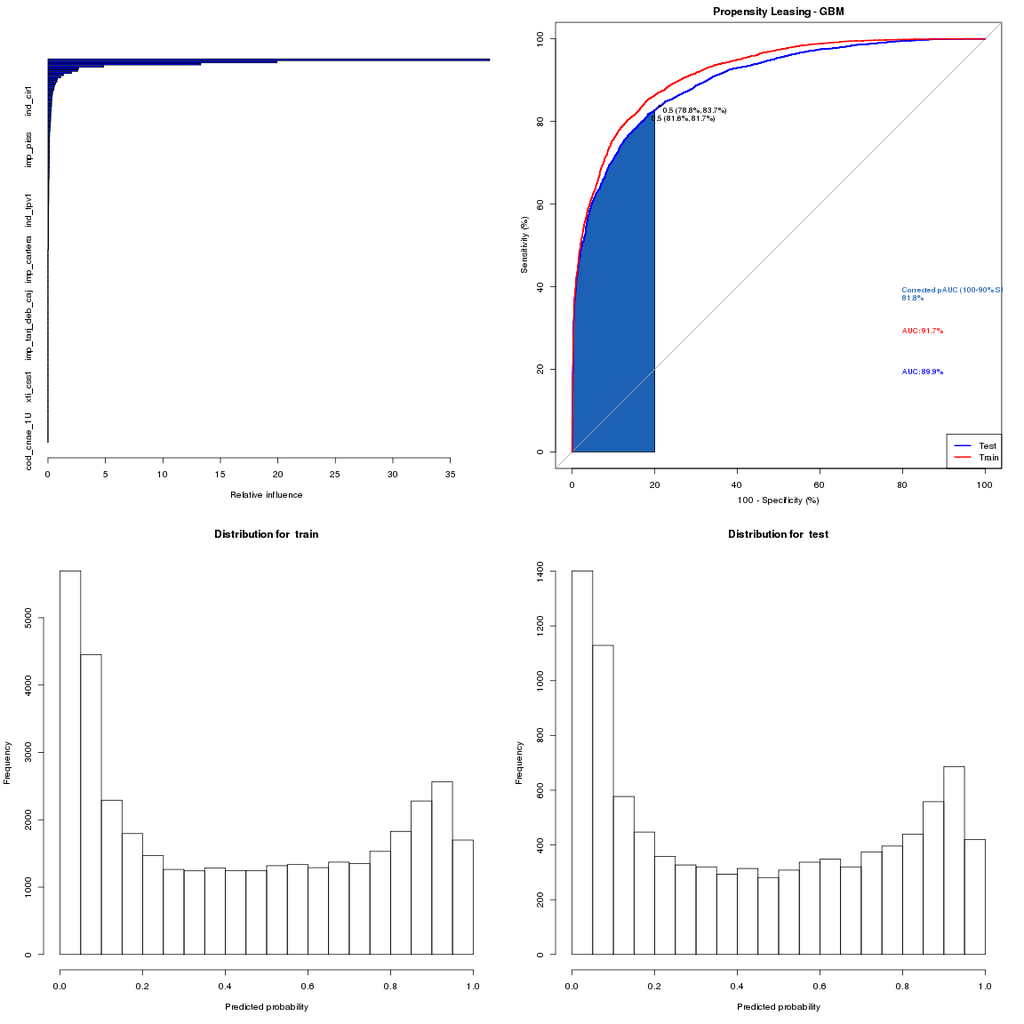

## Train a Random Forest

```r
set.seed(42)
system.time(model.rf <- train(model.formula, data = train.leasing,
                  method = "rf",
                  subset = sample.train,
                  trControl = ctrl,
                  verbose = FALSE,
                  metric = "ROC")
)
```

```
##     user   system  elapsed
## 4128.674    8.952 4138.015
```

```r
#model.rf
#varImp(model.rf)

summarizeModelResults("Propension Leasing - Random Forest", model.rf,  train.leasing, sample.train, test.leasing)
```

```
## Random Forest
##
## 38538 samples
##   269 predictors
##     2 classes: 'Yes', 'No'
##
## No pre-processing
## Resampling: Cross-Validated (10 fold, repeated 1 times)
##
## Summary of sample sizes: 9001, 9000, 9000, 9000, 9000, 9000, ...
##
## Resampling results across tuning parameters:
##
##   mtry  ROC    Sens   Spec   ROC SD   Sens SD  Spec SD
##   2     0.863  0.725  0.814  0.0101   0.0161   0.016
##   90    0.901  0.799  0.821  0.00826  0.0195   0.0175
##   179   0.898  0.797  0.821  0.00875  0.0166   0.0171
##
## ROC was used to select the optimal model using  the largest value.
## The final value used for the model was mtry = 90.
##    TrainROC TrainSens TrainSpec method
## 1 0.9011572 0.7985922 0.8208864     rf
##                 Length Class      Mode
## call                5  -none-     call
## type                1  -none-     character
## predicted       10000  factor     numeric
## err.rate         1500  -none-     numeric
## confusion           6  -none-     numeric
## votes           20000  matrix     numeric
## oob.times       10000  -none-     numeric
## classes             2  -none-     character
## importance        179  -none-     numeric
## importanceSD        0  -none-     NULL
## localImportance     0  -none-     NULL
## proximity           0  -none-     NULL
## ntree               1  -none-     numeric
## mtry                1  -none-     numeric
## forest             14  -none-     list
## y               10000  factor     numeric
## test                0  -none-     NULL
## inbag               0  -none-     NULL
## xNames            179  -none-     character
## problemType         1  -none-     character
## tuneValue           1  data.frame list
## obsLevels           2  -none-     character
```

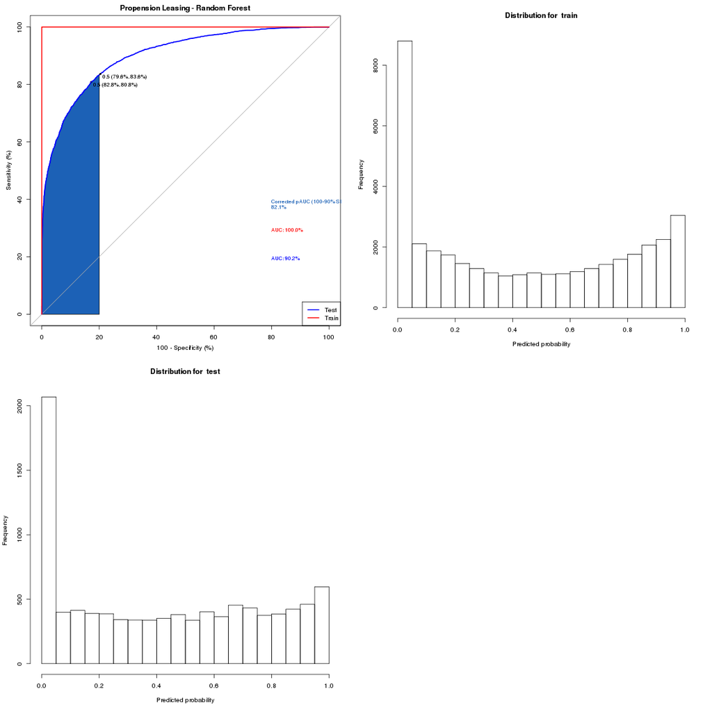

## Train a Logistic Regression

```r
set.seed(42)
system.time(model.glm <- train(model.formula, data = train.leasing, preProcess = c("center", "scale"),
                  method = "glm", family="binomial",
                  subset = sample.train,
                  trControl = ctrl,
                  metric = "ROC")
)
```

```
##    user  system elapsed
## 123.180   0.673 123.869
```

```r
model.glm$finalModel
```

```
##
## Call:  NULL
##
## Coefficients:
##                      (Intercept)                              edad
##                       -1.932e+02                         3.061e-02
##                    xti_idefisco3                     xti_idefisco7
##                        8.591e-03                         1.402e+00
##               antiguedad_cliente                    n_agrupaciones
##                       -1.057e-02                         8.775e-02
##                     n_categorias           media_mens_cta_personal
##                       -8.932e-01                        -1.824e-01
##                        imp_plazo                        imp_fondos
##                       -2.522e-01                        -5.373e-02
##                imp_val_rentavble                 imp_val_rentafija
##                       -5.063e-02                         8.083e-03
##                     imp_estables                 imp_prest_consumo
##                               NA                         2.279e-01
##               imp_prest_hipoteca                        imp_pasivo
##                        7.786e-02                         7.562e-01
##                       imp_avales                       imp_cartera
##                       -1.858e+00                         5.000e-01
##                imp_cesion_nompen             imp_comercio_exterior
##                        4.205e-02                         2.114e-01
##             imp_cesion_impuestos                    imp_confirming
##                        1.194e-01                         1.335e-01
##         imp_confirming_proveedor              imp_factoring_deudor
##                        4.759e-01                         8.539e-02
##                    imp_factoring            imp_pagos_certificados
##                        1.766e-01                         2.716e-01
##                      imp_renting             cod_segmento_global36
##                       -2.455e-01                         2.058e-01
##                         imp_piss                     seg_planunoCP
##                        5.941e-02                         3.440e-01
##                    seg_planunoCR                     seg_planunoCT
##                        3.701e-01                         3.041e-01
##                    seg_planunoCV                    ind_lineabbva1
##                        3.110e-01                         2.148e-02
##              n_agrupaciones_evol                 n_categorias_evol
##                       -2.500e-01                         2.618e-01
```

[output cut: 133 more lines]

```
##                       -2.494e-01                        -2.331e-01
##                      cod_cnae_1O                       cod_cnae_1P
##                       -2.688e-01                        -6.328e-02
##                      cod_cnae_1Q                       cod_cnae_1R
##                       -2.381e-01                        -1.409e-01
##                      cod_cnae_1S                       cod_cnae_1T
##                       -1.153e-01                        -2.807e-01
##                      cod_cnae_1U                    imp_activo_new
##                        2.398e-01                        -5.195e+00
##                  imp_rid_sba_new                   imp_rid_ban_new
##                        4.136e+00                         2.354e+00
##
## Degrees of Freedom: 9999 Total (i.e. Null);  9822 Residual
## Null Deviance:       13710
## Residual Deviance: 7937  AIC: 8293
```

```r
#varImp(model.glm)

#summarizeModelResults("Propension Leasing - GLM", model.glm,  train.leasing, sample.train, test.leasing)
```

## Compare Importance

Vemos qué variables son las importantes con cada uno de los modelos entrenados. Obtenemos las 20 más importantes con cada modelo.

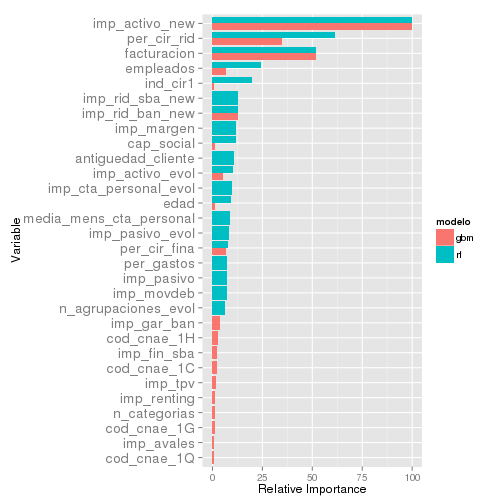

```r
top = 20

imp.gbm <- varImp(model.gbm)$importance
names(imp.gbm) <- "imp"
imp.gbm$var <- rownames(imp.gbm)
imp.gbm <- head(imp.gbm[order(imp.gbm$imp, decreasing = TRUE),], top)

imp.rf <- varImp(model.rf)$importance
names(imp.rf) <- "imp"
imp.rf$var <- rownames(imp.rf)
imp.rf <- head(imp.rf[order(imp.rf$imp, decreasing = TRUE),], top)


importance <- rbind(data.frame(modelo="gbm", imp.gbm),
                    data.frame(modelo="rf", imp.rf))

ggplot(importance, aes(x=reorder(var, imp, max), y=imp, fill=modelo)) + geom_bar(stat="identity", position="dodge") +
  xlab("Variable") + ylab("Relative Importance") + coord_flip() + theme(axis.text.y = element_text(size=14))
```

```r
varImp(model.glm)
```

```
## glm variable importance
##
##   only 20 most important variables shown (out of 177)
##
##                          Overall
## imp_activo_new            100.00
## ind_cir1                   98.19
## cod_cnae_1H                94.62
## cod_cnae_1C                91.50
## cod_cnae_1G                90.94
## cod_cnae_1F                64.39
## cod_cnae_1Q                55.79
## cod_cnae_1M                54.01
## imp_avales                 52.59
## cod_cnae_1N                51.06
## imp_confirming_proveedor   49.79
## cod_cnae_1I                40.12
## imp_renting                36.20
## ind_tpv1                   35.22
## n_categorias               34.86
## cod_cnae_1J                34.61
## facturacion                34.59
## cod_cnae_1R                34.18
## imp_prest_consumo          33.71
## cod_segmento_global36      32.78
```

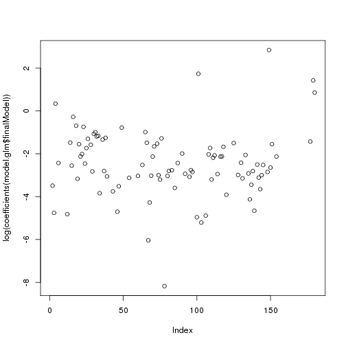

```r
plot(log(coefficients(model.glm$finalModel)))
```

Estimamos la probabildiad para los datos de test.

```r
results <- data.frame(cod_documps1=test.leasing$cod_idefisca,Class = test.leasing$Class)
results$GBM <- predict(model.gbm,
                       newdata = test.leasing,
                       type = "prob")[, 'Yes']

results$RF <- predict(model.rf,
                       newdata = test.leasing,
                       type = "prob")[, 'Yes']
```

Plot ROC curves.

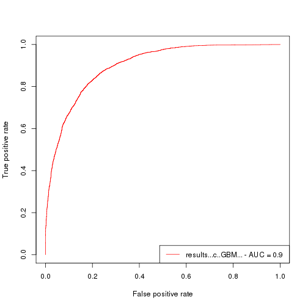

```r
plotMultiRoc(data.frame(results[,c("GBM")]), results$Class, 0, "ROC curves for Several Models")
```

# Distribution of estimated probability wrt class

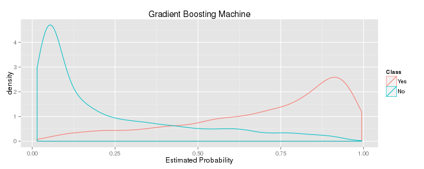

```r
ggplot(results, aes(x=GBM, color=Class)) + geom_density() + xlab("Estimated Probability") + ggtitle("Gradient Boosting Machine")
```

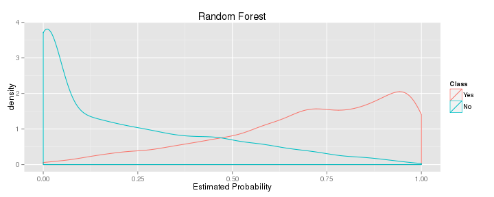

```r
ggplot(results, aes(x=RF, color=Class)) + geom_density() + xlab("Estimated Probability") + ggtitle("Random Forest")
```

# Some statistics

Depending on at which point we consider as positive, we find some customers who doesn't have Leasing currently but with high probability. We compute the estimated probability for every customer and precision and recall for some posible cuts.

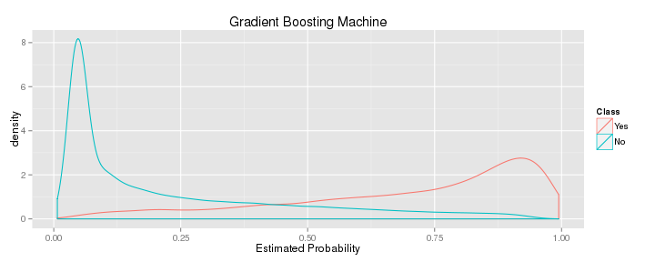

```r
results.all <- data.frame(cod_documps1=df.all$cod_idefisca, Class = df.all$Class)
results.all$GBM <- predict(model.gbm, newdata = df.all, type = "prob")[, 'Yes']
results.all$RF <- predict(model.rf, newdata = df.all, type = "prob")[, 'Yes']

ggplot(results.all, aes(x=GBM, color=Class)) + geom_density() + xlab("Estimated Probability") + ggtitle("Gradient Boosting Machine")
```

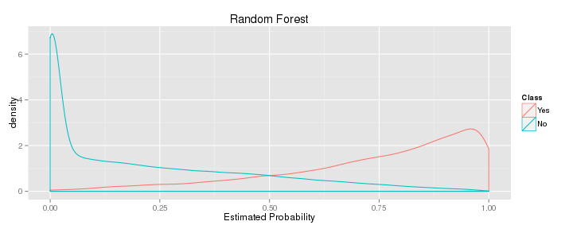

```r
ggplot(results.all, aes(x=RF, color=Class)) + geom_density() + xlab("Estimated Probability") + ggtitle("Random Forest")
```

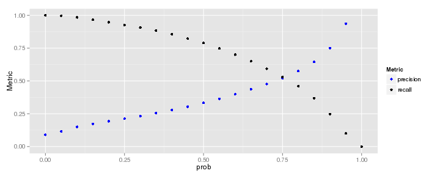

```r
cut <- seq(0, 1, by=0.05)

res <- data.frame()
for (c in cut){
  res <- rbind(res,
               data.frame(prob = c,
                          n = nrow(subset(results.all, GBM > c)),
                          n_nueva = nrow(subset(results.all, GBM > c & Class == 'No')),
                          precision = nrow(subset(results.all, GBM > c & Class == 'Yes'))/nrow(subset(results.all, GBM > c)),
                          recall = nrow(subset(results.all, GBM > c & Class == 'Yes'))/nrow(subset(results.all, Class == 'Yes'))
                          ))
}

# Precision y Recall en el mismo gráfico
ggplot(res, aes(x=prob, y=precision, colour="precision")) + geom_point() +
  geom_point(aes(x=prob, y=recall, colour="recall")) +
  scale_colour_manual(name="Metric", values = c(recall = "black", precision = "blue")) + ylab("Metric")
```

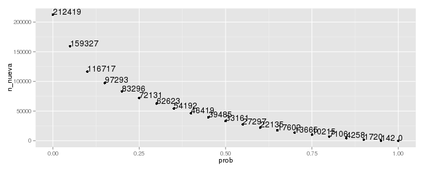

```r
ggplot(res, aes(x=prob, y=n_nueva, label=n_nueva)) + geom_point() + geom_text(hjust=0, vjust=0)
```

# Cómo es la probabilidad según el CNAE

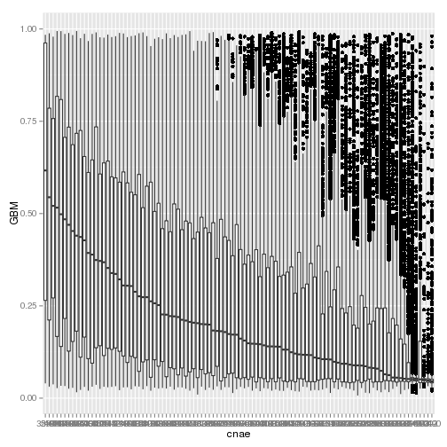

```r
# por cnae
df.cnae <- results.all
df.cnae$cnae <- as.factor(as.character(df.all$cod_cno))

df.cnae <- subset(df.cnae, cnae %in% head(data.table(df.cnae)[,list(n=.N), by=c("cnae")][order(-n)], 100)$cnae)

median <- data.table(df.cnae)[,list(median = median(GBM)), by=c("cnae")][order(-median)]

df.cnae$cnae <- factor(df.cnae$cnae, levels=median$cnae)
ggplot(df.cnae, aes(x=cnae, y=GBM)) + geom_boxplot()
```

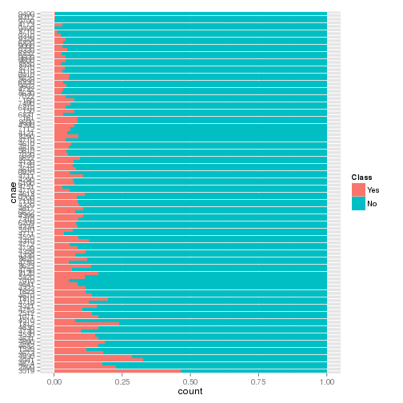

```r
ggplot(df.cnae, aes(x=cnae, fill=Class)) + geom_bar(position="fill") + coord_flip()
```

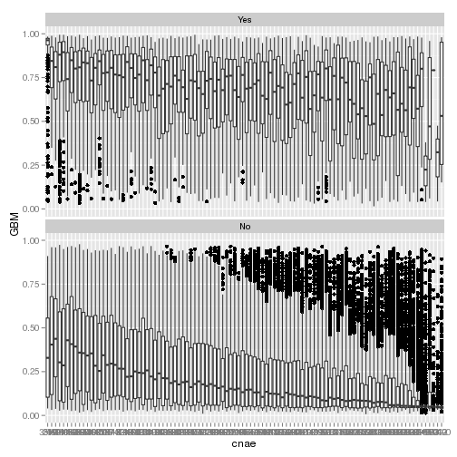

```r
ggplot(df.cnae, aes(x=cnae, y=GBM)) + geom_boxplot() + facet_wrap(~Class, nrow=2)
```

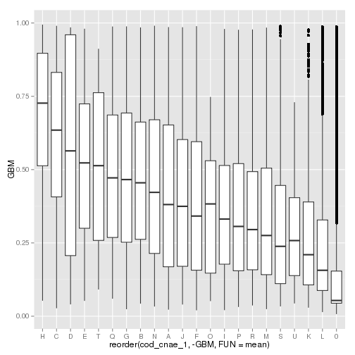

```r
# por grupo de cnae
df.cnae.g <- results.all
df.cnae.g$cod_cnae_1 <- df.all$cod_cnae_1
ggplot(df.cnae.g, aes(x=reorder(cod_cnae_1, -GBM, FUN=mean), y=GBM)) + geom_boxplot()
```

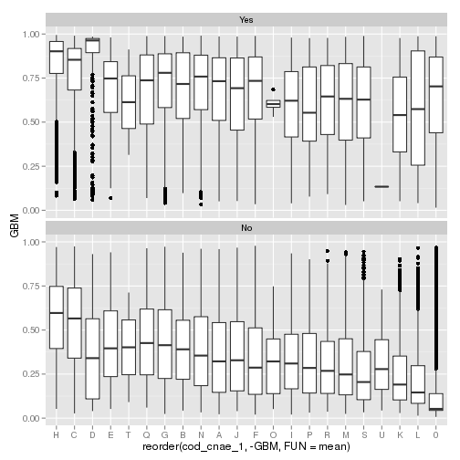

```r
ggplot(df.cnae.g, aes(x=reorder(cod_cnae_1, -GBM, FUN=mean), y=GBM)) + geom_boxplot() + facet_wrap(~Class, nrow=2)
```

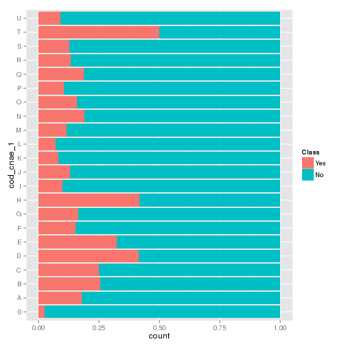

```r
ggplot(df.cnae.g, aes(x=cod_cnae_1, fill=Class)) + geom_bar(position="fill") + coord_flip()
```

```r
data.table(df.cnae.g)[,list(n=.N, p_mean=mean(GBM), p_median=median(GBM)), by=c("cod_cnae_1")]
```

```
##     cod_cnae_1      n    p_mean   p_median
##  1:          0 130042 0.1396773 0.05361266
##  2:          G  27988 0.4797663 0.46594503
##  3:          F  14204 0.3939564 0.34155479
##  4:          A   2317 0.4192033 0.38078897
##  5:          C  13273 0.6047678 0.63467989
##  6:          L   7600 0.2352146 0.15651847
##  7:          M   9389 0.3445011 0.27524298
##  8:          B    227 0.4764882 0.45491633
##  9:          I   7262 0.3639659 0.33133392
## 10:          H   4665 0.6831331 0.72676163
## 11:          S   2033 0.3097774 0.23822234
## 12:          P   1285 0.3582013 0.30619545
## 13:          R   1729 0.3477889 0.29542866
## 14:          Q   2559 0.4884906 0.47173685
## 15:          J   2610 0.4078198 0.37468011
## 16:          N   3702 0.4512279 0.42235427
## 17:          E    300 0.5098869 0.52283257
## 18:          K   1342 0.2748106 0.20967503
## 19:          D    796 0.5551711 0.56380997
## 20:          O     25 0.3644681 0.38279882
## 21:          U     11 0.3012664 0.25789732
## 22:          T      4 0.5075403 0.51346659
##     cod_cnae_1      n    p_mean   p_median
```

```r
dd2 <- data.table(df.cnae.g)[,list(n=.N), by=c("cod_cnae_1", "Class")][,p:=n/sum(n), by=c("cod_cnae_1")]
subset(dd2, Class == "Yes")[order(cod_cnae_1)]
```

```
##     cod_cnae_1 Class    n          p
##  1:          0   Yes 3394 0.02609926
##  2:          A   Yes  415 0.17911092
##  3:          B   Yes   58 0.25550661
##  4:          C   Yes 3332 0.25103594
##  5:          D   Yes  331 0.41582915
##  6:          E   Yes   97 0.32333333
##  7:          F   Yes 2174 0.15305548
##  8:          G   Yes 4576 0.16349864
##  9:          H   Yes 1953 0.41864952
## 10:          I   Yes  719 0.09900854
## 11:          J   Yes  337 0.12911877
## 12:          K   Yes  110 0.08196721
## 13:          L   Yes  539 0.07092105
## 14:          M   Yes 1093 0.11641282
## 15:          N   Yes  705 0.19043760
## 16:          O   Yes    4 0.16000000
## 17:          P   Yes  135 0.10505837
## 18:          Q   Yes  481 0.18796405
## 19:          R   Yes  230 0.13302487
## 20:          S   Yes  258 0.12690605
## 21:          T   Yes    2 0.50000000
## 22:          U   Yes    1 0.09090909
##     cod_cnae_1 Class    n          p
```

```r
data.table(df.cnae)[,list(n=.N, p_mean=mean(GBM), p_median=median(GBM)), by=c("cnae")][order(-p_mean)]
```

```
##      cnae     n     p_mean   p_median
##   1: 3519   731 0.59504564 0.61671504
##   2: 2599   658 0.50487459 0.54417196
##   3: 4674   543 0.50429605 0.52083154
##   4: 4941  3544 0.50257885 0.51601677
##   5: 4930   735 0.48627022 0.49809963
##   6: 4673   866 0.47165276 0.48446129
##   7: 4690  7179 0.45558139 0.44001571
##   8: 1520   618 0.45455134 0.46958014
##   9: 4652   950 0.44996522 0.45270477
##  10: 4631   589 0.43631616 0.43651481
##  11: 1812   586 0.43333513 0.37406274
##  12: 4530   658 0.43077878 0.42748290
##  13: 4630   617 0.41014570 0.38874425
##  14: 2512   930 0.40285015 0.35261275
```

[output cut: 87 more lines]

```r
dd2 <- data.table(df.cnae.g)[,list(n=.N), by=c("cod_cnae_1", "Class")][,p:=n/sum(n), by=c("cod_cnae_1")]
subset(dd2, Class == "Yes")[order(cod_cnae_1)]
```

```
##     cod_cnae_1 Class    n          p
##  1:          0   Yes 3394 0.02609926
##  2:          A   Yes  415 0.17911092
##  3:          B   Yes   58 0.25550661
##  4:          C   Yes 3332 0.25103594
##  5:          D   Yes  331 0.41582915
##  6:          E   Yes   97 0.32333333
##  7:          F   Yes 2174 0.15305548
##  8:          G   Yes 4576 0.16349864
##  9:          H   Yes 1953 0.41864952
## 10:          I   Yes  719 0.09900854
## 11:          J   Yes  337 0.12911877
## 12:          K   Yes  110 0.08196721
## 13:          L   Yes  539 0.07092105
## 14:          M   Yes 1093 0.11641282
## 15:          N   Yes  705 0.19043760
## 16:          O   Yes    4 0.16000000
## 17:          P   Yes  135 0.10505837
## 18:          Q   Yes  481 0.18796405
## 19:          R   Yes  230 0.13302487
## 20:          S   Yes  258 0.12690605
## 21:          T   Yes    2 0.50000000
## 22:          U   Yes    1 0.09090909
##     cod_cnae_1 Class    n          p
```